# Introduction to Data Science Assignment

MSc in Bioinformatics and Computational Biology

Helena Baptista (201406153), Joel Moreira (202008682)

Our dataset was collected from the Real Hospital Portugês in Brasil. This dataset contains information about a large group of pediatric cardiology patients from a group of hospitals.

The maingoal of this work is to classify NORMAL/ABNORMAL pediatric patients in cardiology.

This dataset contains various information about the patients:

- Total of 17873 entries
- Patient's ID#
- Patient's Weight
- Patient's Height
- Patient's Body Mass Index
- Patient's Date of Visit
- Patient's Date of Birth
- Patient's Age
- Patient's Health Insurance
- Patient's Pulse
- Patient's Systolic Blood Pressure
- Patient's Diastolic Blood Pressure
- Patient's SBP/DBP
- Presence or Absense of Pathology
- Patient's Type of Second Heart Sound
- Type of Heart Murmur
- Patient's Cardiac Frequency
- Patient's 1st History of Desease
- Patient's 2nd History of Desease
- Patient's Gender
- Patient's 1st Motive for Consultation
- Patient's 2nd Motive for Consultation

#### Raw Data and Data Preprocessing

1. First step was to load our dataset in order to visualize it.

```python
import pandas as pd
```

```python
df= pd.read_excel("UCMF.xls")
```

```python
df
```

|  | ID | Peso | Altura | IMC | Atendimento | DN | IDADE | Convenio | PULSOS | PA SISTOLICA | ... | PPA | NORMAL X ANORMAL | B2 | SOPRO | FC | HDA 1 | HDA2 | SEXO | MOTIVO1 | MOTIVO2 |
| --- | --- | --- | --- | --- | --- | --- | --- | --- | --- | --- | --- | --- | --- | --- | --- | --- | --- | --- | --- | --- | --- |
| 0 | 1 | 5.0 | 51 | 19.0 | 11/05/06 | 30/03/06 | 0.12 | GS | Normais | NaN | ... | Não Calculado | Anormal | Normal | Sistólico | 112 | Palpitacao | NaN | M | 6 - Suspeita de cardiopatia | 6 - Palpitação/taquicardia/arritmia |
| 1 | 2 | 3.5 | 50 | 14.0 | 25/05/05 | 19/05/05 | 0.02 | GS | Normais | NaN | ... | Não Calculado | Anormal | Normal | ausente | 128 | Dispneia | NaN | M | 6 - Suspeita de cardiopatia | 6 - Dispnéia |
| 2 | 3 | 0.0 | 0 | NaN | 12/06/01 | 08/05/05 | -4.05 | SULA | Normais | NaN | ... | Não Calculado | Anormal | Normal | Sistólico | 88 | Assintomático | NaN | M | 2 - Check-up | NaN |
| 3 | 4 | 8.1 | 65 | 19.0 | 15/10/09 | 21/04/09 | 0.50 | NaN | Normais | NaN | ... | Não Calculado | Anormal | Normal | ausente | 92 | Assintomático | NaN | M | 5 - Parecer cardiológico | NaN |
| 4 | 5 | 39.5 | 142 | 20.0 | 23/01/09 | 24/10/99 | 9.60 | Sulam | Normais | 85.0 | ... | Normal | Anormal | Normal | ausente | 90 | NaN | NaN | M | 5 - Parecer cardiológico | 5 - Atividade física |
| ... | ... | ... | ... | ... | ... | ... | ... | ... | ... | ... | ... | ... | ... | ... | ... | ... | ... | ... | ... | ... | ... |
| 17868 | 17869 | 9.5 | 76 | 16.0 | 03/02/06 | 06/12/04 | 1.20 | NaN | Normais | NaN | ... | Não Calculado | Normal | Normal | ausente | 92 | Assintomático | NaN | Masculino | 5 - Parecer cardiológico | 5 - Cirurgia |
| 17869 | 17870 | 12.0 | 75 | 21.0 | 25/09/09 | 15/12/08 | 0.81 | UR | Normais | NaN | ... | Não Calculado | Normal | Normal | ausente | 90 | Assintomático | NaN | Masculino | 5 - Parecer cardiológico | 5 - Cirurgia |
| 17870 | 17871 | 65.0 | 175 | 21.0 | 03/08/07 | 16/02/84 | 24.34 | Medial | Normais | 126.0 | ... | Não Calculado | Normal | Normal | ausente | 76 | Dor precordial | NaN | Feminino | 1 - Cardiopatia já estabelecida | 1 - Cardiopatia congenica |
| 17871 | 17872 | 27.0 | 134 | 15.0 | 04/10/04 | 03/12/27 | -24.03 | GS | Normais | 90.0 | ... | Não Calculado | Normal | Normal | Sistólico | NaN | NaN | NaN | Feminino | 6 - Suspeita de cardiopatia | 6 - Dor precordial |
| 17872 | 17873 | 44.5 | 0 | NaN | 10/07/03 | 21/07/92 | 11.38 | GS | Normais | 110.0 | ... | Não Calculado | Normais | Normal | ausente | 80 | Dor precordial | NaN | Feminino | 6 - Suspeita de cardiopatia | 6 - Dor precordial |

17873 rows × 21 columns

Just by the first glance of our dataset we can see we have different types of variables. Therefore, we need to acess what those are:

```python
df.dtypes
```

```
ID                    int64
Peso                float64
Altura                int64
IMC                 float64
Atendimento          object
DN                   object
IDADE                object
Convenio             object
PULSOS               object
PA SISTOLICA        float64
PA DIASTOLICA       float64
PPA                  object
NORMAL X ANORMAL     object
B2                   object
SOPRO                object
FC                   object
HDA 1                object
HDA2                 object
SEXO                 object
MOTIVO1              object
MOTIVO2              object
dtype: object
```

From this we can conclude that we have only 2 int variables and 4 floats. The remainder are considered to be categorical which can represent a problem in some of them.

The next step is to remove any duplicates, if there is any.

```python
df.drop_duplicates()
```

|  | ID | Peso | Altura | IMC | Atendimento | DN | IDADE | Convenio | PULSOS | PA SISTOLICA | ... | PPA | NORMAL X ANORMAL | B2 | SOPRO | FC | HDA 1 | HDA2 | SEXO | MOTIVO1 | MOTIVO2 |
| --- | --- | --- | --- | --- | --- | --- | --- | --- | --- | --- | --- | --- | --- | --- | --- | --- | --- | --- | --- | --- | --- |
| 0 | 1 | 5.0 | 51 | 19.0 | 11/05/06 | 30/03/06 | 0.12 | GS | Normais | NaN | ... | Não Calculado | Anormal | Normal | Sistólico | 112 | Palpitacao | NaN | M | 6 - Suspeita de cardiopatia | 6 - Palpitação/taquicardia/arritmia |
| 1 | 2 | 3.5 | 50 | 14.0 | 25/05/05 | 19/05/05 | 0.02 | GS | Normais | NaN | ... | Não Calculado | Anormal | Normal | ausente | 128 | Dispneia | NaN | M | 6 - Suspeita de cardiopatia | 6 - Dispnéia |
| 2 | 3 | 0.0 | 0 | NaN | 12/06/01 | 08/05/05 | -4.05 | SULA | Normais | NaN | ... | Não Calculado | Anormal | Normal | Sistólico | 88 | Assintomático | NaN | M | 2 - Check-up | NaN |
| 3 | 4 | 8.1 | 65 | 19.0 | 15/10/09 | 21/04/09 | 0.50 | NaN | Normais | NaN | ... | Não Calculado | Anormal | Normal | ausente | 92 | Assintomático | NaN | M | 5 - Parecer cardiológico | NaN |
| 4 | 5 | 39.5 | 142 | 20.0 | 23/01/09 | 24/10/99 | 9.60 | Sulam | Normais | 85.0 | ... | Normal | Anormal | Normal | ausente | 90 | NaN | NaN | M | 5 - Parecer cardiológico | 5 - Atividade física |
| ... | ... | ... | ... | ... | ... | ... | ... | ... | ... | ... | ... | ... | ... | ... | ... | ... | ... | ... | ... | ... | ... |
| 17868 | 17869 | 9.5 | 76 | 16.0 | 03/02/06 | 06/12/04 | 1.20 | NaN | Normais | NaN | ... | Não Calculado | Normal | Normal | ausente | 92 | Assintomático | NaN | Masculino | 5 - Parecer cardiológico | 5 - Cirurgia |
| 17869 | 17870 | 12.0 | 75 | 21.0 | 25/09/09 | 15/12/08 | 0.81 | UR | Normais | NaN | ... | Não Calculado | Normal | Normal | ausente | 90 | Assintomático | NaN | Masculino | 5 - Parecer cardiológico | 5 - Cirurgia |
| 17870 | 17871 | 65.0 | 175 | 21.0 | 03/08/07 | 16/02/84 | 24.34 | Medial | Normais | 126.0 | ... | Não Calculado | Normal | Normal | ausente | 76 | Dor precordial | NaN | Feminino | 1 - Cardiopatia já estabelecida | 1 - Cardiopatia congenica |
| 17871 | 17872 | 27.0 | 134 | 15.0 | 04/10/04 | 03/12/27 | -24.03 | GS | Normais | 90.0 | ... | Não Calculado | Normal | Normal | Sistólico | NaN | NaN | NaN | Feminino | 6 - Suspeita de cardiopatia | 6 - Dor precordial |
| 17872 | 17873 | 44.5 | 0 | NaN | 10/07/03 | 21/07/92 | 11.38 | GS | Normais | 110.0 | ... | Não Calculado | Normais | Normal | ausente | 80 | Dor precordial | NaN | Feminino | 6 - Suspeita de cardiopatia | 6 - Dor precordial |

17873 rows × 21 columns

After the former were acessed, we performed preliminary plot analysis:

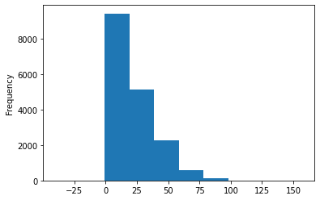

```python
df['Peso'].plot.hist()
```

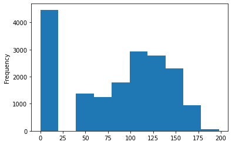

```python
df['Altura'].plot.hist()
```

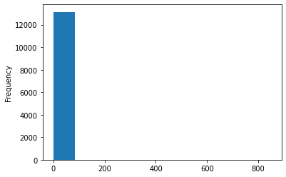

```python
df['IMC'].plot.hist()
```

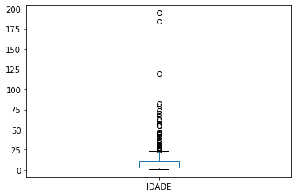

```python
df['IDADE'].value_counts().plot.box()
```

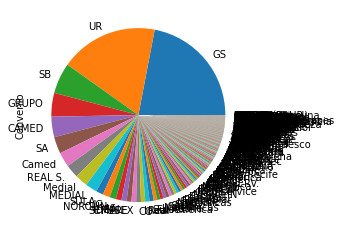

```python
df['Convenio'].value_counts().plot.pie()
```

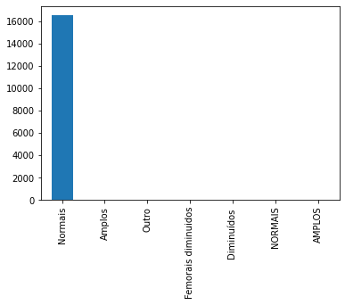

```python
df['PULSOS'].value_counts().plot.bar()
```

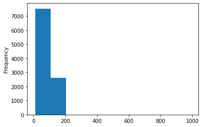

```python
df['PA SISTOLICA'].plot.hist()
```

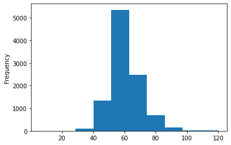

```python
df['PA DIASTOLICA'].plot.hist()
```

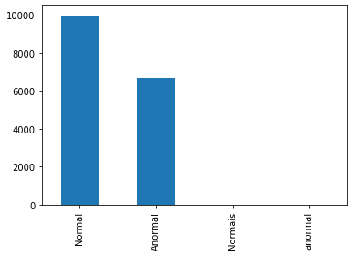

```python
df['NORMAL X ANORMAL'].value_counts().plot.bar()
```

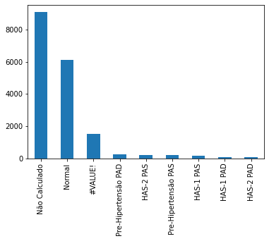

```python
df['PPA'].value_counts().plot.bar()
```

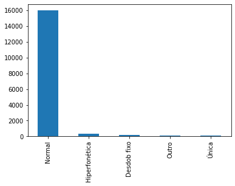

```python
df['B2'].value_counts().plot.bar()
```

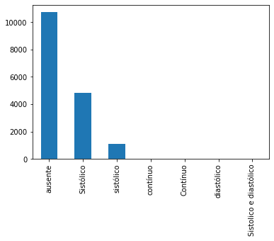

```python
df['SOPRO'].value_counts().plot.bar()
```

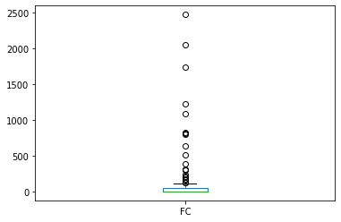

```python
df['FC'].value_counts().plot.box()
```

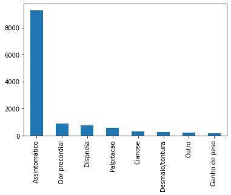

```python
df['HDA 1'].value_counts().plot.bar()
```

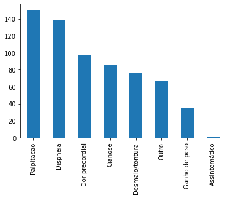

```python
df['HDA2'].value_counts().plot.bar()
```

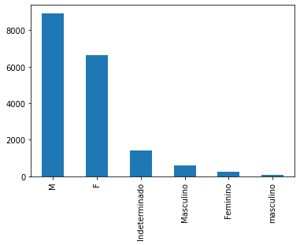

```python
df['SEXO'].value_counts().plot.bar()
```

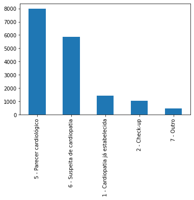

```python
df['MOTIVO1'].value_counts().plot.bar()
```

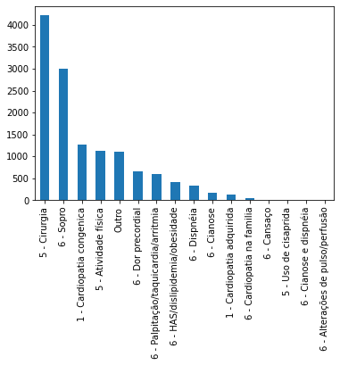

```python
df['MOTIVO2'].value_counts().plot.bar()
```

After visualising all the plots and data we proceeded to:

- Standardize all the data - Diferent names are used to refer to the same thing (Example: "Masculino","masculino" and "M");
- Correct variables that are int and were being consider "object";
- Delete nonsense data such as negative ages.
- Remove variables that contain too many missing values -- more than 50% missing values
- Remove variables that won't be important for the model (health insurance variable, for example).

All of these were easily done with the help of Excel.

With the preprocessing done we had to start by importing our improved dataset back.

```python
dfnovo=pd.read_excel("UCMF-NOVO.xlsx")
```

```python
dfnovo
```

|  | ID | IDADE | PESO | ALTURA | ALTURA2 | IMC | IMC2 | PULSOS | PA SISTOLICA | PA DIASTOLICA | NORMAL X ANORMAL | B2 | SOPRO | FC | Unnamed: 14 | HDA 1 | SEXO | MOTIVO1 | MOTIVO2 |
| --- | --- | --- | --- | --- | --- | --- | --- | --- | --- | --- | --- | --- | --- | --- | --- | --- | --- | --- | --- |
| 0 | 14712 | 2.01 | 12.0 | 87 | 0.87 | 16 | 9.08280 | NORMAIS | 90 | 60 | NORMAL | NORMAL | AUSENTE | 110 | NaN | ASSINTOMÁTICO | M | 6 - Suspeita de cardiopatia | 6 - Sopro |
| 1 | 12862 | 2.05 | 11.0 | 86 | 0.86 | 15 | 8.13560 | NORMAIS | 90 | 60 | ANORMAL | NORMAL | SISTÓLICO | 100 | NaN | NONE | M | 5 - Parecer cardiológico | 5 - Cirurgia |
| 2 | 6793 | 2.05 | 18.3 | 99 | 0.99 | 19 | 17.93583 | NORMAIS | 90 | 60 | NORMAL | NORMAL | AUSENTE | 88 | NaN | NONE | F | 1 - Cardiopatia já estabelecida | 1 - Cardiopatia congenica |
| 3 | 9260 | 2.09 | 12.0 | 80 | 0.80 | 19 | 7.68000 | DIMINUÍDOS | 130 | 80 | ANORMAL | NORMAL | SISTÓLICO | 120 | NaN | DOR PRECORDIAL | F | 5 - Parecer cardiológico | 5 - Atividade física |
| 4 | 14483 | 2.09 | 11.6 | 88 | 0.88 | 15 | 8.98304 | NORMAIS | 95 | 60 | ANORMAL | NORMAL | SISTÓLICO | 90 | NaN | DESMAIO/TONTURA | M | 6 - Suspeita de cardiopatia | Outro |
| ... | ... | ... | ... | ... | ... | ... | ... | ... | ... | ... | ... | ... | ... | ... | ... | ... | ... | ... | ... |
| 6824 | 3062 | 18.91 | 46.0 | 158 | 1.58 | 18 | 114.83440 | NORMAIS | 110 | 70 | NORMAL | NORMAL | AUSENTE | 100 | NaN | DISPNEIA | F | 6 - Suspeita de cardiopatia | 6 - HAS/dislipidemia/obesidade |
| 6825 | 8144 | 19.01 | 60.0 | 185 | 1.85 | 18 | 205.35000 | NORMAIS | 120 | 70 | NORMAL | NORMAL | AUSENTE | 88 | NaN | ASSINTOMÁTICO | M | 5 - Parecer cardiológico | 5 - Cirurgia |
| 6826 | 4460 | 19.04 | 57.0 | 168 | 1.68 | 20 | 160.87680 | NORMAIS | 120 | 90 | ANORMAL | OUTRO | SISTÓLICO | 88 | NaN | GANHO DE PESO | M | 5 - Parecer cardiológico | NaN |
| 6827 | 10995 | 19.42 | 77.0 | 167 | 1.67 | 28 | 214.74530 | NORMAIS | 120 | 70 | NORMAL | NORMAL | AUSENTE | 80 | NaN | OUTRO | F | 5 - Parecer cardiológico | NaN |
| 6828 | 9044 | 19.44 | 54.0 | 153 | 1.53 | 23 | 126.40860 | NORMAIS | 105 | 60 | NORMAL | NORMAL | AUSENTE | 66 | NaN | ASSINTOMÁTICO | F | 6 - Suspeita de cardiopatia | 6 - HAS/dislipidemia/obesidade |

6829 rows × 19 columns

In order to see the difference between the previous unpreprocessed data and our preprocessed data, we analyzed the variable types and plotted some variables again.

```python
dfnovo.dtypes
```

```
ID                    int64
IDADE               float64
PESO                float64
ALTURA                int64
ALTURA2             float64
IMC                   int64
IMC2                float64
PULSOS               object
PA SISTOLICA          int64
PA DIASTOLICA         int64
NORMAL X ANORMAL     object
B2                   object
SOPRO                object
FC                    int64
Unnamed: 14         float64
HDA 1                object
SEXO                 object
MOTIVO1              object
MOTIVO2              object
dtype: object
```

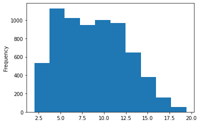

```python
dfnovo["IDADE"].plot.hist()
```

```python
dfnovo = dfnovo.astype({"IDADE": int})
```

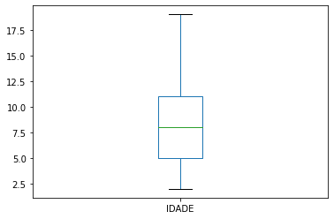

```python
dfnovo["IDADE"].plot.box()
```

As the last step of our preprocessing, we corrected the variables Height and Weight by guiging ourselves throught the supporting material tables and eliminated the nonsense values.

#### Analysis and Predictive Models

```python
dfinal=pd.read_excel("UCMF-NOVO 1.xlsx")
```

```python
dfinal
```

|  | ID | IDADE | PESO | ALTURA | ALTURA2 | IMC | IMC2 | PULSOS | PA SISTOLICA | PA DIASTOLICA | NORMAL X ANORMAL | B2 | SOPRO | FC | HDA 1 | SEXO | MOTIVO1 | MOTIVO2 |
| --- | --- | --- | --- | --- | --- | --- | --- | --- | --- | --- | --- | --- | --- | --- | --- | --- | --- | --- |
| 0 | 5 | 9.60 | 39.5 | 142 | 1.42 | 20 | 79.64780 | NORMAIS | 85 | 50 | ANORMAL | NORMAL | AUSENTE | 90 | ASSINTOMÁTICO | M | 6 - Suspeita de cardiopatia | Outro |
| 1 | 6 | 4.40 | 26.0 | 112 | 1.12 | 21 | 32.61440 | NORMAIS | 100 | 60 | ANORMAL | DESDOB | AUSENTE | 100 | ASSINTOMÁTICO | M | 5 - Parecer cardiológico | 5 - Atividade física |
| 2 | 8 | 5.89 | 28.0 | 117 | 1.17 | 20 | 38.32920 | NORMAIS | 110 | 65 | ANORMAL | NORMAL | AUSENTE | 80 | NONE | M | 6 - Suspeita de cardiopatia | 6 - Sopro |
| 3 | 11 | 6.24 | 24.5 | 122 | 1.22 | 16 | 36.46580 | NORMAIS | 100 | 65 | ANORMAL | NORMAL | SISTÓLICO | 88 | ASSINTOMÁTICO | M | 5 - Parecer cardiológico | 5 - Cirurgia |
| 4 | 17 | 2.72 | 10.5 | 89 | 0.89 | 13 | 8.31705 | NORMAIS | 90 | 60 | NORMAL | NORMAL | AUSENTE | 95 | ASSINTOMÁTICO | F | 5 - Parecer cardiológico | NaN |
| ... | ... | ... | ... | ... | ... | ... | ... | ... | ... | ... | ... | ... | ... | ... | ... | ... | ... | ... |
| 6814 | 17854 | 4.07 | 20.0 | 112 | 1.12 | 16 | 25.08800 | NORMAIS | 100 | 60 | ANORMAL | NORMAL | AUSENTE | 96 | DISPNEIA | F | 6 - Suspeita de cardiopatia | 6 - Dispnéia |
| 6815 | 17859 | 6.60 | 33.8 | 131 | 1.31 | 20 | 58.00418 | NORMAIS | 80 | 50 | NORMAL | NORMAL | SISTÓLICO | 100 | ASSINTOMÁTICO | M | 5 - Parecer cardiológico | 5 - Cirurgia |
| 6816 | 17860 | 8.31 | 35.6 | 135 | 1.35 | 20 | 64.88100 | NORMAIS | 100 | 60 | ANORMAL | NORMAL | AUSENTE | 72 | ASSINTOMÁTICO | F | 5 - Parecer cardiológico | 5 - Atividade física |
| 6817 | 17862 | 8.23 | 43.0 | 138 | 1.38 | 23 | 81.88920 | NORMAIS | 100 | 60 | ANORMAL | NORMAL | AUSENTE | 82 | ASSINTOMÁTICO | M | 5 - Parecer cardiológico | NaN |
| 6818 | 17868 | 2.14 | 10.6 | 85 | 0.85 | 15 | 7.65850 | NORMAIS | 90 | 50 | NORMAL | NORMAL | AUSENTE | 100 | ASSINTOMÁTICO | F | 5 - Parecer cardiológico | 5 - Cirurgia |

6819 rows × 18 columns

We started our Analysis by transforming variables into dummy variables in order to make correlations and Multiple Linear Regression.

```python
#Transformation of the variables in X to dummies
X = dfinal[['IDADE', 'PESO', 'ALTURA', 'IMC', 'PULSOS', 'PA SISTOLICA', 'PA DIASTOLICA', 'B2', 'SOPRO', 'FC', 'HDA 1', 'SEXO']]
X = pd.get_dummies(data=X, drop_first=True)
X.head()
```

|  | IDADE | PESO | ALTURA | IMC | PA SISTOLICA | PA DIASTOLICA | FC | PULSOS_DIMINUÍDOS | PULSOS_NONE | PULSOS_NORMAIS | PULSOS_OUTRO | B2_HIPERFONÉTICA | B2_NORMAL | B2_OUTRO | B2_ÚNICA | SOPRO_CONTÍNUO | SOPRO_DIASTÓLICO | SOPRO_S&D | SOPRO_SISTÓLICO | HDA 1_CIANOSE | HDA 1_DESMAIO/TONTURA | HDA 1_DISPNEIA | HDA 1_DOR PRECORDIAL | HDA 1_GANHO DE PESO | HDA 1_NONE | HDA 1_OUTRO | HDA 1_PALPITAÇÃO | SEXO_M |
| --- | --- | --- | --- | --- | --- | --- | --- | --- | --- | --- | --- | --- | --- | --- | --- | --- | --- | --- | --- | --- | --- | --- | --- | --- | --- | --- | --- | --- |
| 0 | 9.60 | 39.5 | 142 | 20 | 85 | 50 | 90 | 0 | 0 | 1 | 0 | 0 | 1 | 0 | 0 | 0 | 0 | 0 | 0 | 0 | 0 | 0 | 0 | 0 | 0 | 0 | 0 | 1 |
| 1 | 4.40 | 26.0 | 112 | 21 | 100 | 60 | 100 | 0 | 0 | 1 | 0 | 0 | 0 | 0 | 0 | 0 | 0 | 0 | 0 | 0 | 0 | 0 | 0 | 0 | 0 | 0 | 0 | 1 |
| 2 | 5.89 | 28.0 | 117 | 20 | 110 | 65 | 80 | 0 | 0 | 1 | 0 | 0 | 1 | 0 | 0 | 0 | 0 | 0 | 0 | 0 | 0 | 0 | 0 | 0 | 1 | 0 | 0 | 1 |
| 3 | 6.24 | 24.5 | 122 | 16 | 100 | 65 | 88 | 0 | 0 | 1 | 0 | 0 | 1 | 0 | 0 | 0 | 0 | 0 | 1 | 0 | 0 | 0 | 0 | 0 | 0 | 0 | 0 | 1 |
| 4 | 2.72 | 10.5 | 89 | 13 | 90 | 60 | 95 | 0 | 0 | 1 | 0 | 0 | 1 | 0 | 0 | 0 | 0 | 0 | 0 | 0 | 0 | 0 | 0 | 0 | 0 | 0 | 0 | 0 |

```python
#Transformation of the target variable in dummy.
Y=dfinal[['NORMAL X ANORMAL']]
Y = pd.get_dummies(data=Y, drop_first=True)
Y.head()
```

|  | NORMAL X ANORMAL_NORMAL |
| --- | --- |
| 0 | 0 |
| 1 | 0 |
| 2 | 0 |
| 3 | 0 |
| 4 | 1 |

After, we perform a Bivariate analysis with the variables "X" that have a stronger correlation with our target variable "Y".

```python
import pandas.plotting
```

```python
import seaborn as sns
```

```python
allf=dfinal[['IDADE', 'PESO', 'ALTURA', 'IMC', 'PULSOS', 'PA SISTOLICA', 'PA DIASTOLICA', 'B2', 'SOPRO', 'FC', 'HDA 1', 'SEXO', 'NORMAL X ANORMAL']]
allf = pd.get_dummies(data=allf, drop_first=True)
allf.head()
```

|  | IDADE | PESO | ALTURA | IMC | PA SISTOLICA | PA DIASTOLICA | FC | PULSOS_DIMINUÍDOS | PULSOS_NONE | PULSOS_NORMAIS | PULSOS_OUTRO | B2_HIPERFONÉTICA | B2_NORMAL | B2_OUTRO | B2_ÚNICA | SOPRO_CONTÍNUO | SOPRO_DIASTÓLICO | SOPRO_S&D | SOPRO_SISTÓLICO | HDA 1_CIANOSE | HDA 1_DESMAIO/TONTURA | HDA 1_DISPNEIA | HDA 1_DOR PRECORDIAL | HDA 1_GANHO DE PESO | HDA 1_NONE | HDA 1_OUTRO | HDA 1_PALPITAÇÃO | SEXO_M | NORMAL X ANORMAL_NORMAL |
| --- | --- | --- | --- | --- | --- | --- | --- | --- | --- | --- | --- | --- | --- | --- | --- | --- | --- | --- | --- | --- | --- | --- | --- | --- | --- | --- | --- | --- | --- |
| 0 | 9.60 | 39.5 | 142 | 20 | 85 | 50 | 90 | 0 | 0 | 1 | 0 | 0 | 1 | 0 | 0 | 0 | 0 | 0 | 0 | 0 | 0 | 0 | 0 | 0 | 0 | 0 | 0 | 1 | 0 |
| 1 | 4.40 | 26.0 | 112 | 21 | 100 | 60 | 100 | 0 | 0 | 1 | 0 | 0 | 0 | 0 | 0 | 0 | 0 | 0 | 0 | 0 | 0 | 0 | 0 | 0 | 0 | 0 | 0 | 1 | 0 |
| 2 | 5.89 | 28.0 | 117 | 20 | 110 | 65 | 80 | 0 | 0 | 1 | 0 | 0 | 1 | 0 | 0 | 0 | 0 | 0 | 0 | 0 | 0 | 0 | 0 | 0 | 1 | 0 | 0 | 1 | 0 |
| 3 | 6.24 | 24.5 | 122 | 16 | 100 | 65 | 88 | 0 | 0 | 1 | 0 | 0 | 1 | 0 | 0 | 0 | 0 | 0 | 1 | 0 | 0 | 0 | 0 | 0 | 0 | 0 | 0 | 1 | 0 |
| 4 | 2.72 | 10.5 | 89 | 13 | 90 | 60 | 95 | 0 | 0 | 1 | 0 | 0 | 1 | 0 | 0 | 0 | 0 | 0 | 0 | 0 | 0 | 0 | 0 | 0 | 0 | 0 | 0 | 0 | 1 |

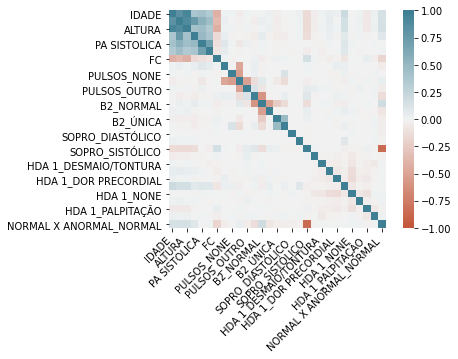

```python
corr = allf.corr()
ax = sns.heatmap(
    corr,
    vmin=-1, vmax=1, center=0,
    cmap=sns.diverging_palette(20, 220, n=200),
    square=True
)
ax.set_xticklabels(
    ax.get_xticklabels(),
    rotation=45,
    horizontalalignment='right'
);
```

Since our main goal is to classify a patient as "NORMAL" or "ABNORMAL", we can see by the correlation plot above, a strong negative correlation in this variable with "SOPRO_SISTÓLICO" and some weaker correlations with "IDADE","PESO","ALTURA","PA SISTÓLICA", "FC", "B2_HIPERFONETICA", "B2_NORMAL" and "B2_OUTRO".

To better understand the relation between out target variable and the others mentioned we performed regression:

```python
import statsmodels.api as sm
```

```python
I = dfinal["ALTURA"]
J=dfinal[['NORMAL X ANORMAL']]
J = pd.get_dummies(data=Y, drop_first=True)

# fd
model = sm.OLS(J, I).fit()
predictions = model.predict(I) # make the predictions by the model

# Print out the statistics
model.summary()
```

OLS Regression Results

| Dep. Variable: | NORMAL X ANORMAL_NORMAL | R-squared (uncentered): | -20.829 |
| --- | --- | --- | --- |
| Model: | OLS | Adj. R-squared (uncentered): | -20.833 |
| Method: | Least Squares | F-statistic: | -6506. |
| Date: | Sat, 16 Jan 2021 | Prob (F-statistic): | 1.00 |
| Time: | 08:11:15 | Log-Likelihood: | -4576.1 |
| No. Observations: | 6819 | AIC: | 9154. |
| Df Residuals: | 6818 | BIC: | 9161. |
| Df Model: | 1 |  |  |
| Covariance Type: | nonrobust |  |  |

|  | coef | std err | t | P>\|t\| | [0.025 | 0.975] |
| --- | --- | --- | --- | --- | --- | --- |
| ALTURA | 0.0049 | 4.35e-05 | 113.633 | 0.000 | 0.005 | 0.005 |

| Omnibus: | 48330.324 | Durbin-Watson: | 1.941 |
| --- | --- | --- | --- |
| Prob(Omnibus): | 0.000 | Jarque-Bera (JB): | 981.031 |
| Skew: | -0.576 | Prob(JB): | 9.37e-214 |
| Kurtosis: | 1.541 | Cond. No. | 1.00 |

Notes:  
[1] R² is computed without centering (uncentered) since the model does not contain a constant.  
[2] Standard Errors assume that the covariance matrix of the errors is correctly specified.

```python
I = dfinal["IDADE"]
J=dfinal[['NORMAL X ANORMAL']]
J = pd.get_dummies(data=Y, drop_first=True)

# fd
model = sm.OLS(J, I).fit()
predictions = model.predict(I) # make the predictions by the model

# Print out the statistics
model.summary()
```

OLS Regression Results

| Dep. Variable: | NORMAL X ANORMAL_NORMAL | R-squared (uncentered): | -24.368 |
| --- | --- | --- | --- |
| Model: | OLS | Adj. R-squared (uncentered): | -24.372 |
| Method: | Least Squares | F-statistic: | -6549. |
| Date: | Sat, 16 Jan 2021 | Prob (F-statistic): | 1.00 |
| Time: | 08:11:18 | Log-Likelihood: | -5088.3 |
| No. Observations: | 6819 | AIC: | 1.018e+04 |
| Df Residuals: | 6818 | BIC: | 1.019e+04 |
| Df Model: | 1 |  |  |
| Covariance Type: | nonrobust |  |  |

|  | coef | std err | t | P>\|t\| | [0.025 | 0.975] |
| --- | --- | --- | --- | --- | --- | --- |
| IDADE | 0.0653 | 0.001 | 100.797 | 0.000 | 0.064 | 0.067 |

| Omnibus: | 1427.763 | Durbin-Watson: | 1.875 |
| --- | --- | --- | --- |
| Prob(Omnibus): | 0.000 | Jarque-Bera (JB): | 472.176 |
| Skew: | -0.432 | Prob(JB): | 2.94e-103 |
| Kurtosis: | 2.044 | Cond. No. | 1.00 |

Notes:  
[1] R² is computed without centering (uncentered) since the model does not contain a constant.  
[2] Standard Errors assume that the covariance matrix of the errors is correctly specified.

```python
I = dfinal["PA SISTOLICA"]
J=dfinal[['NORMAL X ANORMAL']]
J = pd.get_dummies(data=Y, drop_first=True)

# fd
model = sm.OLS(J, I).fit()
predictions = model.predict(I) # make the predictions by the model

# Print out the statistics
model.summary()
```

OLS Regression Results

| Dep. Variable: | NORMAL X ANORMAL_NORMAL | R-squared (uncentered): | -21.709 |
| --- | --- | --- | --- |
| Model: | OLS | Adj. R-squared (uncentered): | -21.712 |
| Method: | Least Squares | F-statistic: | -6518. |
| Date: | Sat, 16 Jan 2021 | Prob (F-statistic): | 1.00 |
| Time: | 08:11:22 | Log-Likelihood: | -4710.8 |
| No. Observations: | 6819 | AIC: | 9424. |
| Df Residuals: | 6818 | BIC: | 9430. |
| Df Model: | 1 |  |  |
| Covariance Type: | nonrobust |  |  |

|  | coef | std err | t | P>\|t\| | [0.025 | 0.975] |
| --- | --- | --- | --- | --- | --- | --- |
| PA SISTOLICA | 0.0064 | 5.77e-05 | 110.219 | 0.000 | 0.006 | 0.006 |

| Omnibus: | 38984.456 | Durbin-Watson: | 1.951 |
| --- | --- | --- | --- |
| Prob(Omnibus): | 0.000 | Jarque-Bera (JB): | 1095.732 |
| Skew: | -0.613 | Prob(JB): | 1.16e-238 |
| Kurtosis: | 1.466 | Cond. No. | 1.00 |

Notes:  
[1] R² is computed without centering (uncentered) since the model does not contain a constant.  
[2] Standard Errors assume that the covariance matrix of the errors is correctly specified.

```python
I = dfinal["FC"]
J=dfinal[['NORMAL X ANORMAL']]
J = pd.get_dummies(data=Y, drop_first=True)

# fd
model = sm.OLS(J, I).fit()
predictions = model.predict(I) # make the predictions by the model

# Print out the statistics
model.summary()
```

OLS Regression Results

| Dep. Variable: | NORMAL X ANORMAL_NORMAL | R-squared (uncentered): | -23.262 |
| --- | --- | --- | --- |
| Model: | OLS | Adj. R-squared (uncentered): | -23.266 |
| Method: | Least Squares | F-statistic: | -6537. |
| Date: | Sat, 16 Jan 2021 | Prob (F-statistic): | 1.00 |
| Time: | 08:11:25 | Log-Likelihood: | -4936.4 |
| No. Observations: | 6819 | AIC: | 9875. |
| Df Residuals: | 6818 | BIC: | 9882. |
| Df Model: | 1 |  |  |
| Covariance Type: | nonrobust |  |  |

|  | coef | std err | t | P>\|t\| | [0.025 | 0.975] |
| --- | --- | --- | --- | --- | --- | --- |
| FC | 0.0073 | 7.01e-05 | 104.566 | 0.000 | 0.007 | 0.007 |

| Omnibus: | 39942.391 | Durbin-Watson: | 1.936 |
| --- | --- | --- | --- |
| Prob(Omnibus): | 0.000 | Jarque-Bera (JB): | 1079.178 |
| Skew: | -0.608 | Prob(JB): | 4.57e-235 |
| Kurtosis: | 1.477 | Cond. No. | 1.00 |

Notes:  
[1] R² is computed without centering (uncentered) since the model does not contain a constant.  
[2] Standard Errors assume that the covariance matrix of the errors is correctly specified.

```python
I = dfinal["B2"]
I = pd.get_dummies(data=I, drop_first=True)
J=dfinal[['NORMAL X ANORMAL']]
J = pd.get_dummies(data=J, drop_first=True)

# fd
model = sm.OLS(J, I).fit()
predictions = model.predict(I) # make the predictions by the model

# Print out the statistics
model.summary()
```

OLS Regression Results

| Dep. Variable: | NORMAL X ANORMAL_NORMAL | R-squared (uncentered): | -20.459 |
| --- | --- | --- | --- |
| Model: | OLS | Adj. R-squared (uncentered): | -20.471 |
| Method: | Least Squares | F-statistic: | -1624. |
| Date: | Sat, 16 Jan 2021 | Prob (F-statistic): | 1.00 |
| Time: | 08:11:29 | Log-Likelihood: | -4517.7 |
| No. Observations: | 6819 | AIC: | 9043. |
| Df Residuals: | 6815 | BIC: | 9071. |
| Df Model: | 4 |  |  |
| Covariance Type: | nonrobust |  |  |

|  | coef | std err | t | P>\|t\| | [0.025 | 0.975] |
| --- | --- | --- | --- | --- | --- | --- |
| HIPERFONÉTICA | 0.0312 | 0.059 | 0.533 | 0.594 | -0.084 | 0.146 |
| NORMAL | 0.6631 | 0.006 | 115.031 | 0.000 | 0.652 | 0.674 |
| OUTRO | 0.2453 | 0.064 | 3.804 | 0.000 | 0.119 | 0.372 |
| ÚNICA | 0.1000 | 0.148 | 0.674 | 0.501 | -0.191 | 0.391 |

| Omnibus: | 46182.197 | Durbin-Watson: | 1.946 |
| --- | --- | --- | --- |
| Prob(Omnibus): | 0.000 | Jarque-Bera (JB): | 1127.396 |
| Skew: | -0.671 | Prob(JB): | 1.55e-245 |
| Kurtosis: | 1.528 | Cond. No. | 25.8 |

Notes:  
[1] R² is computed without centering (uncentered) since the model does not contain a constant.  
[2] Standard Errors assume that the covariance matrix of the errors is correctly specified.

```python
I = dfinal["PESO"]
J=dfinal[['NORMAL X ANORMAL']]
J = pd.get_dummies(data=Y, drop_first=True)

# fd
model = sm.OLS(J, I).fit()
predictions = model.predict(I) # make the predictions by the model

# Print out the statistics
model.summary()
```

OLS Regression Results

| Dep. Variable: | NORMAL X ANORMAL_NORMAL | R-squared (uncentered): | -25.029 |
| --- | --- | --- | --- |
| Model: | OLS | Adj. R-squared (uncentered): | -25.032 |
| Method: | Least Squares | F-statistic: | -6556. |
| Date: | Sat, 16 Jan 2021 | Prob (F-statistic): | 1.00 |
| Time: | 08:11:34 | Log-Likelihood: | -5176.0 |
| No. Observations: | 6819 | AIC: | 1.035e+04 |
| Df Residuals: | 6818 | BIC: | 1.036e+04 |
| Df Model: | 1 |  |  |
| Covariance Type: | nonrobust |  |  |

|  | coef | std err | t | P>\|t\| | [0.025 | 0.975] |
| --- | --- | --- | --- | --- | --- | --- |
| PESO | 0.0173 | 0.000 | 98.637 | 0.000 | 0.017 | 0.018 |

| Omnibus: | 988.732 | Durbin-Watson: | 1.863 |
| --- | --- | --- | --- |
| Prob(Omnibus): | 0.000 | Jarque-Bera (JB): | 482.625 |
| Skew: | -0.493 | Prob(JB): | 1.58e-105 |
| Kurtosis: | 2.147 | Cond. No. | 1.00 |

Notes:  
[1] R² is computed without centering (uncentered) since the model does not contain a constant.  
[2] Standard Errors assume that the covariance matrix of the errors is correctly specified.

Linear regression is the most simple and important ‘Machine Learning’ algorithm.

```python
import numpy as np
```

```python
from sklearn.linear_model import LinearRegression
```

```python
from sklearn.model_selection import train_test_split
X_train, X_test, y_train, y_test = train_test_split(X, Y, test_size=0.4, random_state=101)
print(X_train.shape)
print(X_test.shape)
print(y_train.shape)
print(y_test.shape)
```

```
(4091, 28)
(2728, 28)
(4091, 1)
(2728, 1)
```

```python
model = LinearRegression()
model.fit(X_train,y_train)
```

```
LinearRegression()
```

LinearRegression(copy_X=True, fit_intercept=True, n_jobs=None, normalize=False)

```python
print(model.intercept_)
```

```
[1.10992645]
```

```python
predictions = model.predict(X_test)
predictions
```

```
array([[-0.003529  ],
       [ 0.9296078 ],
       [ 0.95202569],
       ...,
       [ 0.92694485],
       [ 0.95479175],
       [ 0.91227031]])
```

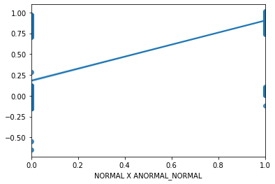

```python
sns.regplot(y_test,predictions)
```

```python
import statsmodels.api as sm
X_train_Sm= sm.add_constant(X_train)
X_train_Sm= sm.add_constant(X_train)
ls=sm.OLS(y_train,X_train_Sm).fit()
print(ls.summary())
```

```
                               OLS Regression Results
===================================================================================
Dep. Variable:     NORMAL X ANORMAL_NORMAL   R-squared:                       0.735
Model:                                 OLS   Adj. R-squared:                  0.733
Method:                      Least Squares   F-statistic:                     401.9
Date:                     Sat, 16 Jan 2021   Prob (F-statistic):               0.00
Time:                             08:11:58   Log-Likelihood:                -67.668
No. Observations:                     4091   AIC:                             193.3
Df Residuals:                         4062   BIC:                             376.5
Df Model:                               28
Covariance Type:                 nonrobust
=========================================================================================
                            coef    std err          t      P>|t|      [0.025      0.975]
-----------------------------------------------------------------------------------------
const                     1.1099      0.173      6.409      0.000       0.770       1.449
IDADE                    -0.0002      0.003     -0.065      0.948      -0.006       0.006
PESO                      0.0003      0.002      0.202      0.840      -0.003       0.003
ALTURA                    0.0003      0.001      0.319      0.750      -0.002       0.002
IMC                      -0.0031      0.003     -0.940      0.347      -0.010       0.003
PA SISTOLICA             -0.0005      0.001     -0.929      0.353      -0.002       0.001
PA DIASTOLICA            -0.0003      0.001     -0.395      0.693      -0.002       0.001
FC                       -0.0018      0.000     -4.638      0.000      -0.003      -0.001
PULSOS_DIMINUÍDOS        -0.5905      0.157     -3.759      0.000      -0.898      -0.283
PULSOS_NONE              -0.0069      0.147     -0.047      0.962      -0.295       0.281
PULSOS_NORMAIS           -0.0501      0.111     -0.451      0.652      -0.268       0.168
PULSOS_OUTRO             -0.0338      0.157     -0.215      0.830      -0.342       0.274
B2_HIPERFONÉTICA         -0.0656      0.059     -1.105      0.269      -0.182       0.051
B2_NORMAL                 0.0989      0.042      2.345      0.019       0.016       0.182
B2_OUTRO                 -0.0760      0.061     -1.246      0.213      -0.196       0.044
B2_ÚNICA                  0.0454      0.174      0.260      0.795      -0.297       0.388
SOPRO_CONTÍNUO           -0.8650      0.154     -5.612      0.000      -1.167      -0.563
SOPRO_DIASTÓLICO         -0.6655      0.124     -5.378      0.000      -0.908      -0.423
SOPRO_S&D                -0.9025      0.249     -3.619      0.000      -1.391      -0.414
SOPRO_SISTÓLICO          -0.8666      0.009    -99.829      0.000      -0.884      -0.850
HDA 1_CIANOSE             0.0093      0.043      0.215      0.830      -0.076       0.095
HDA 1_DESMAIO/TONTURA     0.0210      0.026      0.818      0.414      -0.029       0.071
HDA 1_DISPNEIA           -0.0113      0.019     -0.602      0.547      -0.048       0.025
HDA 1_DOR PRECORDIAL      0.0042      0.015      0.278      0.781      -0.025       0.034
HDA 1_GANHO DE PESO      -0.0185      0.033     -0.566      0.571      -0.083       0.046
HDA 1_NONE                0.0121      0.010      1.248      0.212      -0.007       0.031
HDA 1_OUTRO              -0.0420      0.034     -1.233      0.218      -0.109       0.025
HDA 1_PALPITAÇÃO          0.0008      0.019      0.040      0.968      -0.037       0.039
SEXO_M                   -0.0099      0.008     -1.262      0.207      -0.025       0.006
==============================================================================
Omnibus:                     1894.718   Durbin-Watson:                   2.025
Prob(Omnibus):                  0.000   Jarque-Bera (JB):            18354.028
Skew:                          -1.966   Prob(JB):                         0.00
Kurtosis:                      12.603   Cond. No.                     1.39e+04
==============================================================================

Notes:
[1] Standard Errors assume that the covariance matrix of the errors is correctly specified.
[2] The condition number is large, 1.39e+04. This might indicate that there are
strong multicollinearity or other numerical problems.
```

All the variables were used in the model.

We use adjusted R-squared to compare the goodness-of-fit for regression models that contain different numbers of independent variables. The R-squared varies between 0 and 1 (or %), having a better fit if closer to 1 (100).

Our Linear-Regression Model presents a R-squared of 0.73 which is very good. However this model cannot be used convictely as our final model since the result of the same will be a number and that not indicate if a patient is "NORMAL" or "ANORMAL".

We decided to use aglomerative hierarchical clustering to identify similiar groups of patients. With this method of cluster analysis, each cohort member starts as its own cluster. The 2 most similar clusters are merged and this new cluster replaces the former 2. The process continues until there is only 1 cluster containing all observations.

Various algorithms are available for cluster analysis. For this study, we used Ward’s minimum variance method as the primary algorithm because it was already used in similar studies.

```python
import matplotlib.pyplot as plt
```

```python
import scipy.cluster.hierarchy as sch
```

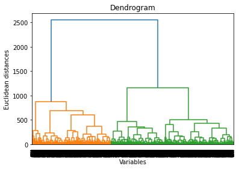

```python
dendrogram = sch.dendrogram(sch.linkage(X, method  = "ward"))
plt.title('Dendrogram')
plt.xlabel('Variables')
plt.ylabel('Euclidean distances')
plt.show()
```

With the dendogram above we find out the optimal number of clusters to use.

```python
from sklearn.cluster import AgglomerativeClustering
hc = AgglomerativeClustering(n_clusters = 3, affinity = 'euclidean', linkage ='ward')
```

```python
y_hc=hc.fit_predict(X)
```

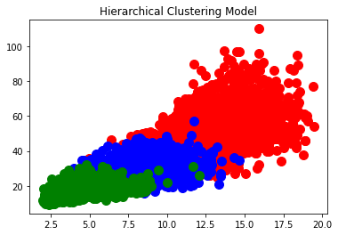

```python
X=np.array(X)
plt.scatter(X[y_hc==0, 0], X[y_hc==0, 1], s=100, c='red', label ='Cluster 1')
plt.scatter(X[y_hc==1, 0], X[y_hc==1, 1], s=100, c='blue', label ='Cluster 2')
plt.scatter(X[y_hc==2, 0], X[y_hc==2, 1], s=100, c='green', label ='Cluster 3')
plt.title('Hierarchical Clustering Model')
plt.xlabel('')
plt.ylabel('')
plt.show()
```

In order to start the supervised machine learning models we tried to make a Decision Tree

```python
target=dfinal[['NORMAL X ANORMAL']]
ov=dfinal[['IDADE', 'PESO', 'ALTURA', 'IMC', 'PULSOS', 'PA SISTOLICA', 'PA DIASTOLICA', 'B2', 'SOPRO', 'FC', 'HDA 1', 'SEXO']]
```

```
[Text(210.32486569133215, 214.5016216216216, 'X[18] <= 0.5\nmse = 0.228\nsamples = 6819\nvalue = 0.648'),
 ...]
```

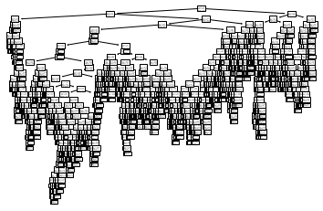

```python
from sklearn.tree import DecisionTreeRegressor
from sklearn import tree
clf1 =tree.DecisionTreeRegressor()
clf1=clf1.fit(X,Y)
tree.plot_tree(clf1)
```

```python
# Import the model we are using
from sklearn.ensemble import RandomForestRegressor
# Instantiate model with 1000 decision trees
rf = RandomForestRegressor(n_estimators = 1000, random_state = 42)
# Train the model on training data
rf.fit(X, Y);
```

```python
# Import tools needed for visualization
from sklearn.tree import export_graphviz
import pydot
# Pull out one tree from the forest
tree = rf.estimators_[5]
```

```python
# Export the image to a dot file
export_graphviz(tree, out_file = 'tree.dot', rounded = True, precision = 1)
```

```python
# Use dot file to create a graph
(graph, ) = pydot.graph_from_dot_file('small_tree.dot')
```

Support Vector Machines:

In case of non-linearly separable data, the simple SVM algorithm cannot be used. Rather, a modified version of SVM, called Kernel SVM, is used.

We used 3 different Kernels:

- Polynomial
- Gaussion
- Signmoid

```python
#SVM Kernel attempt:
dfinal.shape
```

```
(6819, 18)
```

```python
from sklearn.model_selection import train_test_split
X_train, X_test, y_train, y_test = train_test_split(X, Y, test_size = 0.20)
```

```python
#Polynomial Kernel
from sklearn.svm import SVC
svclassifier= SVC(kernel='poly', degree=8)
svclassifier.fit(X_train,y_train)
```

```
SVC(C=1.0, break_ties=False, cache_size=200, class_weight=None, coef0=0.0,
    decision_function_shape='ovr', degree=8, gamma='scale', kernel='poly',
    max_iter=-1, probability=False, random_state=None, shrinking=True,
    tol=0.001, verbose=False)
```

```python
y_pred=svclassifier.predict(X_test)
```

```python
from sklearn.metrics import classification_report, confusion_matrix
print(confusion_matrix(y_test,y_pred))
print(classification_report(y_test,y_pred))
```

```
[[131 317]
 [ 10 906]]
              precision    recall  f1-score   support

           0       0.93      0.29      0.44       448
           1       0.74      0.99      0.85       916

    accuracy                           0.76      1364
   macro avg       0.83      0.64      0.65      1364
weighted avg       0.80      0.76      0.71      1364
```

```python
#GAUSSION KERNEL
from sklearn.svm import SVC
svclassifierG= SVC(kernel='rbf', degree=8)
svclassifierG.fit(X_train,y_train)
```

```
SVC(C=1.0, break_ties=False, cache_size=200, class_weight=None, coef0=0.0,
    decision_function_shape='ovr', degree=8, gamma='scale', kernel='rbf',
    max_iter=-1, probability=False, random_state=None, shrinking=True,
    tol=0.001, verbose=False)
```

```python
y_predG=svclassifierG.predict(X_test)
```

```python
from sklearn.metrics import classification_report, confusion_matrix
print(confusion_matrix(y_test,y_predG))
print(classification_report(y_test,y_predG))
```

```
[[  0 448]
 [  0 916]]
              precision    recall  f1-score   support

           0       0.00      0.00      0.00       448
           1       0.67      1.00      0.80       916

    accuracy                           0.67      1364
   macro avg       0.34      0.50      0.40      1364
weighted avg       0.45      0.67      0.54      1364
```

```python
#SIGMOID KERNEL
from sklearn.svm import SVC
svclassifierS= SVC(kernel='sigmoid', degree=8)
svclassifierS.fit(X_train,y_train)
y_predS=svclassifierS.predict(X_test)
```

```python
from sklearn.metrics import classification_report, confusion_matrix
print(confusion_matrix(y_test,y_predS))
print(classification_report(y_test,y_predS))
```

```
[[163 285]
 [292 624]]
              precision    recall  f1-score   support

           0       0.36      0.36      0.36       448
           1       0.69      0.68      0.68       916

    accuracy                           0.58      1364
   macro avg       0.52      0.52      0.52      1364
weighted avg       0.58      0.58      0.58      1364
```

Comparing the performance of the Kernels we can see that the Gaussion Kernel performed worse.

The Polynomial Kernel had a better performance than the Sigmoid.

In order to complete the Predictive Models we did a Neuronal Network:

```python
#NN method
from sklearn.neural_network import MLPClassifier
from sklearn.model_selection import train_test_split
import pandas as pd
import numpy as np
from sklearn.neural_network import MLPClassifier
from sklearn import preprocessing
from sklearn.model_selection import train_test_split
from sklearn.metrics import confusion_matrix
from sklearn.metrics import accuracy_score

y = Y
x = X
x = preprocessing.scale(x)
model = x_train, x_test, y_train, y_test = train_test_split(x,y, test_size= 0.75, random_state=20000)
print(x_train)
print(y_test)
print(y_train)
```

```
[[-0.12405249  0.3693549  -0.18479285 ... -0.12565929 -0.20731499
   0.84152619]
 [ 0.61989749  0.33578998  0.5647662  ... -0.12565929 -0.20731499
  -1.18831714]
 [-0.09996778 -0.47648109 -0.09109797 ... -0.12565929 -0.20731499
  -1.18831714]
 ...
 [ 0.89553363  0.83926378  0.70530852 ... -0.12565929 -0.20731499
   0.84152619]
 [ 0.66271475  1.6313959   1.03324061 ... -0.12565929 -0.20731499
   0.84152619]
 [-0.6860291  -0.53689795 -0.60641982 ... -0.12565929  4.82357792
  -1.18831714]]
      NORMAL X ANORMAL_NORMAL
4696                        0
3205                        1
995                         0
4290                        1
5779                        1
...                       ...
469                         0
5733                        0
5815                        1
4554                        0
4217                        1

[5115 rows x 1 columns]
      NORMAL X ANORMAL_NORMAL
768                         0
2777                        1
5743                        1
5553                        0
2706                        1
...                       ...
600                         0
711                         1
405                         1
5232                        1
3856                        0

[1704 rows x 1 columns]
```

```python
clf = MLPClassifier(hidden_layer_sizes=(50,), max_iter=500, alpha=0.01,
                     solver='sgd', verbose=0,  random_state=21)
clf.fit(x_train, y_train)
y_pred = clf.predict(x_test)
print(accuracy_score(y_test, y_pred))
cm = confusion_matrix(y_test, y_pred)
print(cm)
```

```
0.9305962854349951
[[1528  268]
 [  87 3232]]
```

#### Conclusions

After concluding the analysis steps using clusters, correlations and a multiple linear regression model, we used 3 different Supervised Machine Learning Models:

- Decision Tree
- SVM
- Neural Network

In the future, we could improve the data during the preprocessing by trying to impute data rather than deleting what didn't suit our parameters.